# RSV (AREXVY) - Sleep disorder

OpenSourcePV

Data Lock Point: 2024_01_26

# 1 Quantitative Signal status

## 1.1 Disproportionality

The vaccine-event combination “RSV (AREXVY) - Sleep disorder” was **a signal of disproportionate reporting** with an EB05 value of 2.05.

The threshold for being flagged as a signal of disproportionate reporting is an EB05>=2 meaning that there there is a 95% probability that the reporting of Sleep disorder was at least twice post exposure to RSV (AREXVY) than post all vaccines [1]. Under the assumption of no causality between RSV (AREXVY) and Sleep disorder and no bias it would have been expected to observe an EBGM of 1.

It means that the quantified causality criterion of strength of association is **met**.

*It is to be noted that the nature of the spontaneous report does not provide reliable estimates of the strength of association (whatever the choice of the disproportionality method) and that some reporting bias or difference in demographic characteristics might explain the (un)observed disproportion*.

## 1.2 Time-to-onset

The vaccine-event combination “RSV (AREXVY) - Sleep disorder” was **not a signal of unexpected time-to-onset distribution** with a p-value of the two-sample Kolmogorov-Smirnov test being 0.6335593 and distance between the two empirical cumulative distributions being of 11.2672374%.

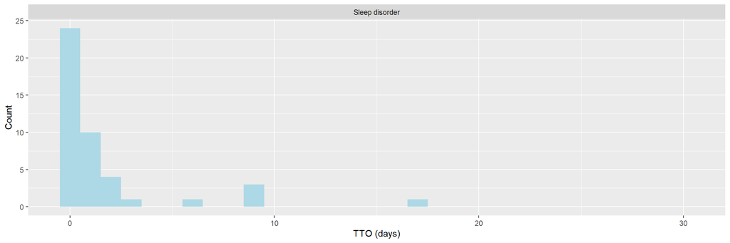

The TTO signal detection method tests if the distribution of Sleep disorder post RSV (AREXVY) is significantly different from the distribution of Sleep disorder post other vaccines using a two-sample Kolmogorov-Smirnov test [2]. The threshold for being flagged as a signal of unexpected time-to-onset distribution is a P-value <0.001 and a distance between the two empirical distributions larger than 20%. Under the assumption of no causality and no bias, it would have been expected that the time-to-onset distribution for “Sleep disorder” would have been the same post RSV (AREXVY) than post other vaccines.

It means that the quantified causality criterion of temporality is **not met**.

*It is to be noted that the nature of the spontaneous report does not provide reliable estimates of the temporal relationship between the exposure and the occurrence of the events as there is the reporting bias over time: the latter the event occurs after exposure, the less chance it has to be reported. Other biases could distort the reported time-to-onset distribution (media attention, etc.)*

## 1.3 Overall

Based on the screening of the Empirical Bayes Geometric Mean (EBGM) and the screening of the time-to-onset distribution,the vaccine-event combination “RSV (AREXVY) - Sleep disorder” is **considered as quantitative signal**.

# 2 Signal History

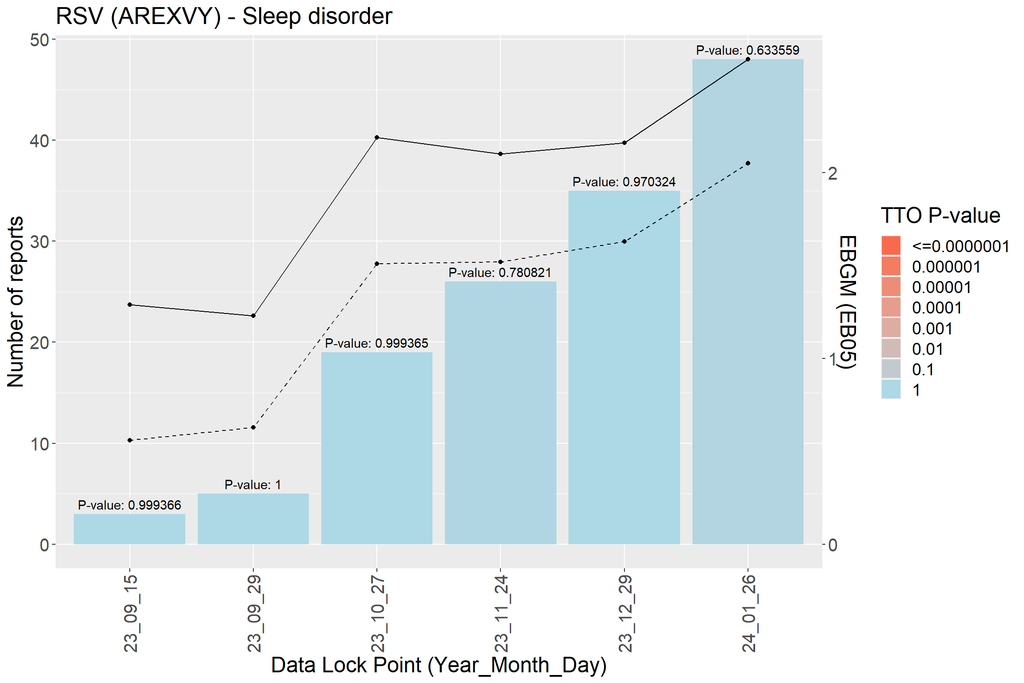